# TNC Integration and Subsidization as a Compliment to Public Transportation

2024-02-08

## Background

- Declining Public Transportation Usage
- Corresponds with the rise of Transportation Network Companies (TNCs)

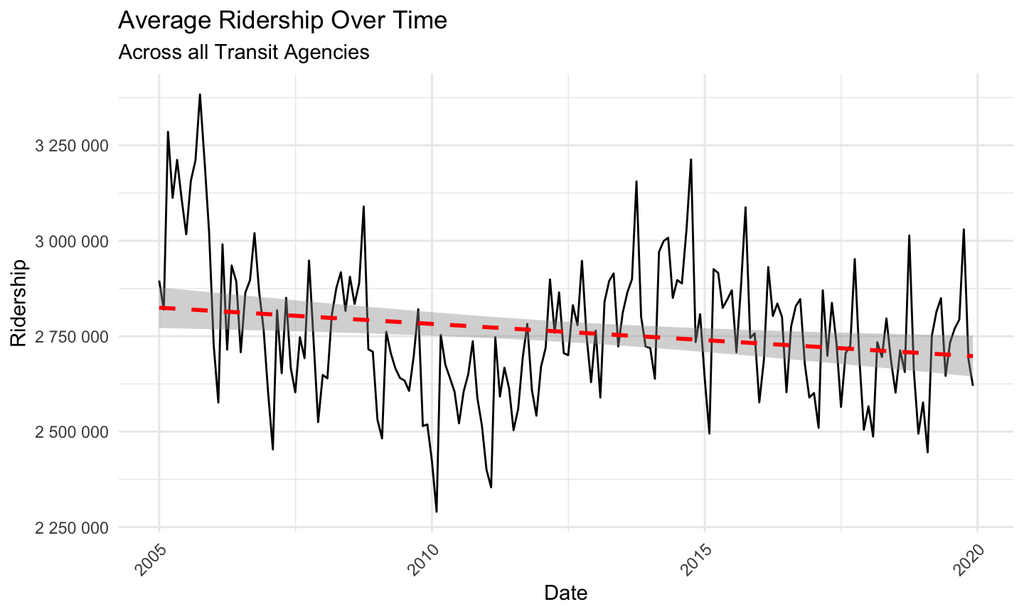

## Background

- Public transit companies partner with TNCs
  - Pinellas County subsidies
  - Atlanta, GA MARTA on the Go

[figure not shown]

## Literature

- Erhardt, et al. (2022) claim TNCs are the biggest driver of transit ridership decline using NTD data
- Hall, et al. (2018) find that TNCs are a net compliment to public transit but lots of variation using diff-in-diff
- Zhao (2019) finds that TNCs are a compliment to good transit, substitute to bad using monocentric city model
- Agrawal, et al. (2023) finds that subsidizing TNCs increases ridership substantially using monocentric city model

## Research Question

- What is the effect on ridership for public transportation agencies that partner with TNCs?
  - Subsidies
  - Promotion(?)

## Methodology

- Difference-in-difference
  - Treatment: Public transportation agencies that partner with TNCs
  - Control: Public transportation agencies that do not partner with TNCs
  - Time: Before and after partnership
- Considerations
  - Subsetting the dataset
  - Partnership times. Will there be enough data post treatment?

## Data Sources

- National Transit Database (NTD)
  - Contains monthly ridership data from 2005-2019 for all public transportation agencies that receive federal funding
- American Community Survey (ACS)
  - Contains yearly demographic data for all urbanized areas (+65,000 population)
  - Consider using CPS (monthly)

```
## # A tibble: 6 × 26
##   agency  date       ridership ntd_id legacy_ntd_id status reporter_type uace_cd
##   <chr>   <date>         <dbl> <chr>  <chr>         <chr>  <chr>         <chr>
## 1 2Plus … 2008-01-01      1144 10110  1110          Inact… Full Reporter 10162
## 2 2Plus … 2008-02-01      1092 10110  1110          Inact… Full Reporter 10162
## 3 2Plus … 2008-03-01      1050 10110  1110          Inact… Full Reporter 10162
## 4 2Plus … 2008-04-01      1100 10110  1110          Inact… Full Reporter 10162
## 5 2Plus … 2008-05-01      1056 10110  1110          Inact… Full Reporter 10162
## 6 2Plus … 2008-06-01      1008 10110  1110          Inact… Full Reporter 10162
## # ℹ 18 more variables: uza_name <chr>, city <chr>, state <chr>, mode <chr>,
## #   tos <chr>, x3_mode <chr>, month <chr>, year <dbl>, geoid <chr>,
## #   med_age <dbl>, pop <dbl>, white <dbl>, black <dbl>, asian <dbl>,
## #   hispanic <dbl>, poverty <dbl>, med_house_income <dbl>, bach <dbl>
```

## Preliminary Results

- Limited to FL
- Diff-in-diff of Pinellas County vs. rest of FL

```
##                                   didreg               didreg_fe
## Dependent Var.:                ridership               ridership
##
## Constant           2,235,049.5*** (29.2)
## pop                      0.372*** (17.9)         0.372*** (17.9)
## white            -3,989,205.8*** (-50.7) -3,989,679.6*** (-50.7)
## med_house_income          26.0*** (22.2)          26.0*** (22.3)
## poverty                 -1.97*** (-10.9)        -1.97*** (-10.9)
## treated              414,098.4*** (19.0)     414,123.9*** (19.0)
## time               -465,046.5*** (-24.8)   -465,860.5*** (-24.8)
## treated x time        -37,688.4 (-0.787)      -37,747.9 (-0.788)
## Fixed-Effects:   ----------------------- -----------------------
## month                                 No                     Yes
## ________________ _______________________ _______________________
## VCOV type                            IID                     IID
## Observations                      13,732                  13,732
## R2                                 0.361                   0.362
## Within R2                             --                   0.361
## ---
## Signif. codes: 0 '***' 0.001 '**' 0.01 '*' 0.05 '.' 0.1 ' ' 1
```

## Potential Issues

- Classifying partnerships/finding information (changes over time)
- Ensuring that all agencies are classified as treated or control correctly

## References

[Agrawal and Zhao, 2023] Agrawal, D. R. and Zhao, W. (2023). Taxing uber. Journal of Public Economics, 221:104862.

[Erhardt et al., 2022] Erhardt, G. D., Hoque, J. M., Goyal, V., Berrebi, S., Brakewood, C., and Watkins, K. E. (2022). Why has public transit ridership declined in the united states? Transportation Research Part A: Policy and Practice, 161:68–87.

[Hall et al., 2018] Hall, J. D., Palsson, C., and Price, J. (2018). Is uber a substitute or complement for public transit? Journal of Urban Economics, 108:36–50.

[Zhao, 2019] Zhao, W. (2019). The long run effects of uber on public transit, congestion, sprawl, and the environment.